# Exploring the BRFSS data

## Setup

### Load packages

```r
library(ggplot2)
theme_set(theme_light())
library(dplyr)
library(tidyr)
library(patchwork)
library(forcats)
```

### Load data

```r
load("brfss2013.RData")
brfss2013 <- brfss2013 %>% as_tibble()
```

## Part 1: Data

**1) What is the description of this data?**

These data are about health surveys that collect state data about U.S. residents regarding their health-related risk behaviors, chronic health conditions, and use of preventive services. Conducted by Behavioral Risk Factor Surveillance System (BRFSS), a collaborative project between all of the states in the United States (US) and participating US territories and the Centers for Disease Control and Prevention (CDC).

**2) Why is this data collected?**

BRFSS has become a powerful tool for targeting and building health promotion activities. The BRFSS objective is to collect uniform, state-specific data on preventive health practices and risk behaviors that are linked to chronic diseases, injuries, and preventable infectious diseases that affect the adult population.

**3) How the observations in the sample are collected?**

A cross-sectional telephone survey that state health departments conduct monthly over landline telephones and cellular telephones with a standardized questionnaire and technical and methodologic assistance from CDC. In order to conduct the BRFSS, states obtain samples of telephone numbers from CDC. States then review their sampling methodology with a state statistician and CDC to make sure data collection procedures are in place to follow the methodology. If any change in sampling methodology is considered, states consult with CDC before making changes.

The BRFSS uses two samples: one for **landline telephone respondents** and one for **cellular telephone respondents**. - The Landline Sample: Disproportionate stratified sampling (DSS) has been used for the landline sample since 2003. The DSS design attempts to find a way of differentiating, before sampling begins, between a set of telephone numbers that contains a large proportion of target numbers (the high-density block) and a set that contains a smaller proportion of target numbers (the medium-density block. DSS sampling telephone numbers is more efficient than **simple random sampling**. - The Cellular Telephone Sample: The cellular telephone sample is randomly generated from a sampling frame of confirmed cellular area code and prefix combinations.

1- Reasoning for generalizability:

As presented in the course, random sampling happens when subjects are selected randomly from the population. We can affirm that BRFSS uses random sampling, as each subject in the population is equally likely to be selected, and the resulting sample is likely representative of the population. So the study’s results are generalizable to the population at large, in this case about U.S. residents. The only point is that BRFSS use randomly generated for cellular telephone respondent’s sample, and disproportionate stratified sampling (a stratified sampling procedure) for landline. P.S. States complete approximately 20% of their completed interviews with respondents on cell phones.

2- Reasoning for causality: On the other hand, the BRFSS does not use random assignment, since it only occurs in experimental settings, where subjects are being assigned to various treatments. Therefore, it is not possible to make causal conclusions based on the study, since we can’t ensure that some different characteristics between subjects are represented equally in the treatment and control groups and consequently don’t allow us to attribute any observed difference between the treatment and control groups.

## Part 2: Research questions

**Research question 1:** What is the total of answers by sex and general Health, and the highest responses by state?

In my first question, I want to see the big picture of the data and have a view of the proportion of general health by sex and the top ten responses by state.

**Research question 2:** What is the relativity of the US citizens who have any health care coverage or could not see dr. because of cost and general Health? Additionally what is the education level, employment status and income level for those who had health care coverage?

The second question is related to the social and economic condition with the medical coverage and how it reflects on general Health.

## Part 3: Exploratory data analysis

**Research question 1**

```r
unique(brfss2013$iyear)
```

```
## [1] 2013 2014 <NA>
## Levels: 2013 2014
```

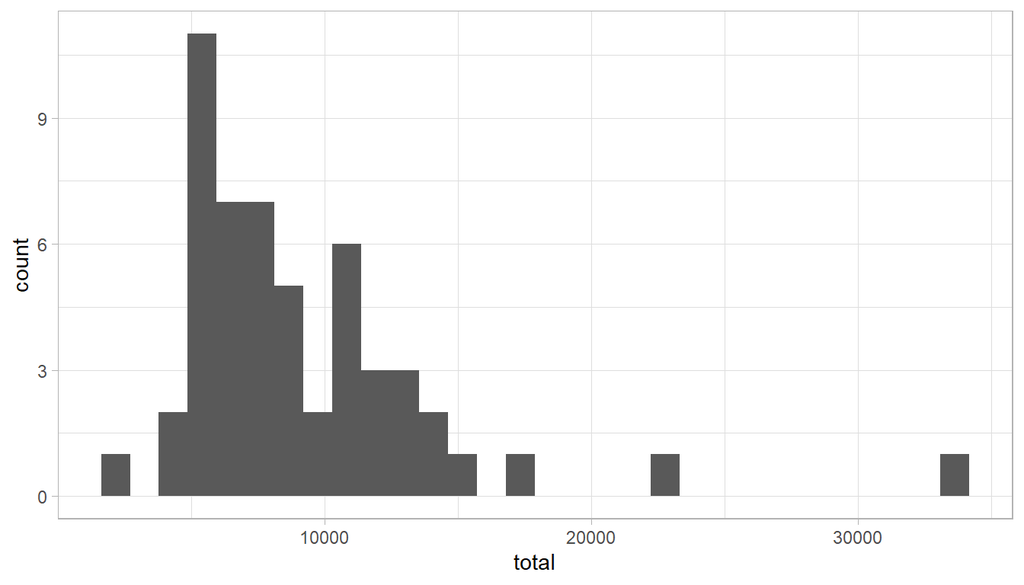

```r
### Make sure that we are only going to look at 2013 data:
group2013 <- brfss2013 %>%
filter(iyear == "2013")

groupstate <- group2013%>%
  group_by(X_state) %>%
  summarise(total = n())

names(groupstate)[names(groupstate) == "n"] <- "total"

## Rename columns
group2013 <- group2013 %>% rename(month = imonth,
                                  health_care = hlthpln1,
                                  general_health = genhlth,
                                  not_dr_cost = medcost,
                                  press_medication = bpmeds,
                                  heart_attack = cvdinfr4,
                                  overweight_obese = X_rfbmi5,
                                  cholest_high = toldhi2,
                                  satisf_life = lsatisfy
                                  )

groupstate %>%
  ggplot(aes(x = total)) +
  geom_histogram()
```

**Evaluation** In this histogram by state we can see that it is a positive skew distribution. This usually happens when it has a few relatively high values and the mean is greater than the median.

```r
groupstate %>%
  arrange(-total) %>%
  head(10)
```

```
## # A tibble: 10 x 2
##    X_state       total
##    <fct>         <int>
##  1 Florida       33316
##  2 Kansas        23096
##  3 Nebraska      17048
##  4 Massachusetts 15071
##  5 Minnesota     14335
##  6 New Jersey    13776
##  7 Colorado      13387
##  8 Maryland      13010
##  9 Michigan      12759
## 10 Ohio          11970
```

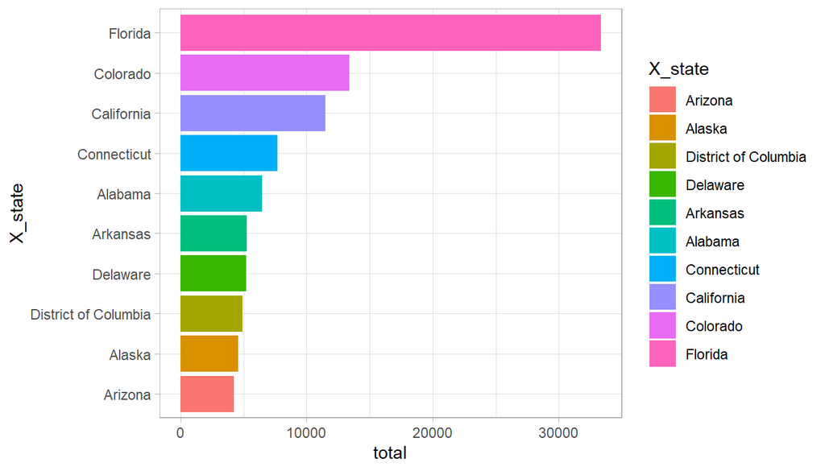

```r
groupstate %>%
  mutate(X_state = fct_reorder(X_state, total)) %>%
  head(10) %>%
  ggplot(aes(x=X_state, y=total, fill=X_state)) +
    geom_bar(stat="identity") +
    coord_flip()
```

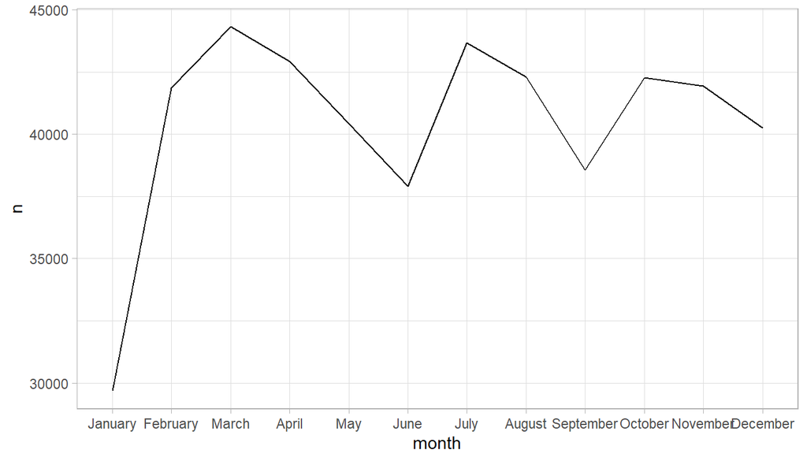

```r
group2013 %>%
  group_by(month) %>%
  summarise(n = n()) %>%
  ggplot(aes(x = month, y = n, group = 1)) +
    geom_line()
```

**Evaluation** January we have fewer respondents than the rest of the year and Florida has the largest number of respondents.

```r
groupsex <- group2013%>%
  group_by(sex) %>%
  summarise(n = n()) %>%
  na.exclude

groupsex$prop <- groupsex$n / sum(groupsex$n)

groupsex %>%
  mutate(prop = prop.table(n),
         prop = sprintf("%0.2f", prop)
         )
```

```
## # A tibble: 2 x 3
##   sex         n prop
##   <fct>   <int> <chr>
## 1 Male   198974 0.41
## 2 Female 287112 0.59
```

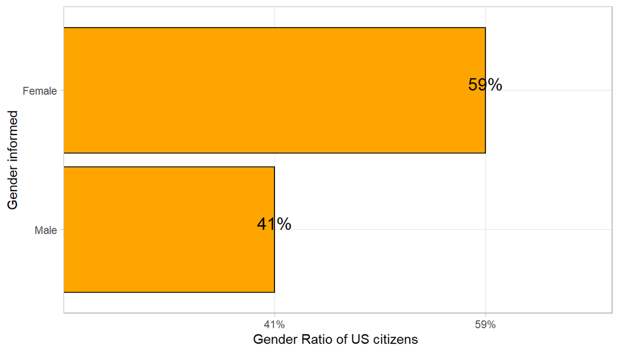

```r
groupsexhlt <- group2013%>%
group_by(sex, general_health) %>%
summarise(n = n())
groupsexhlt <- na.omit(groupsexhlt)

groupsex %>%
  mutate(prop=scales::percent(prop))  %>%
  ggplot(aes(x=sex,y=prop))+
  geom_bar(stat="identity",color='black',fill='orange')+
  xlab("Gender informed")+ylab("Gender Ratio of US citizens ") +
  geom_text(aes(label=prop), position=position_dodge(width=0.4), vjust=0, size = 5) + coord_flip()
```

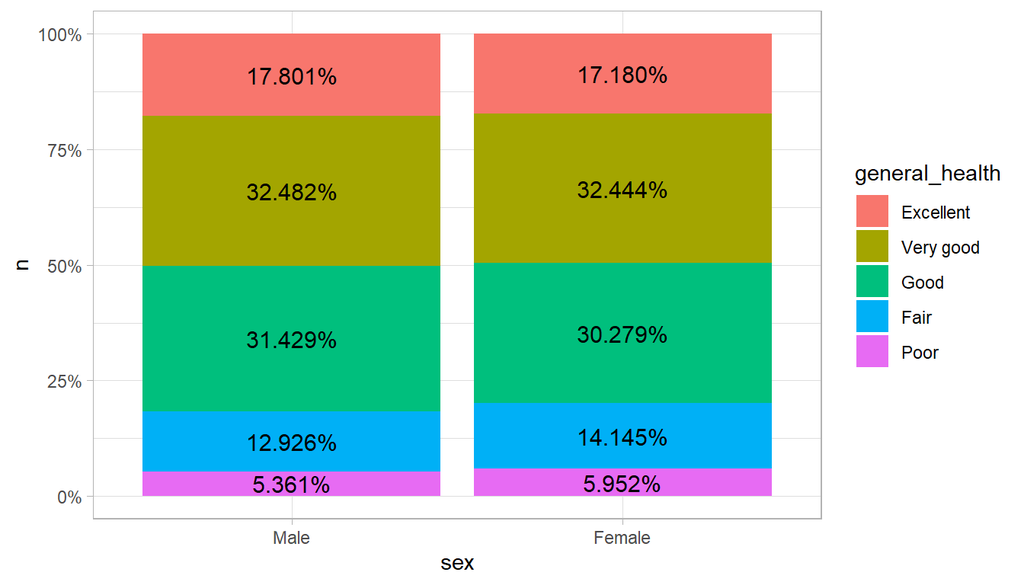

```r
groupsexhlt %>%
     group_by(sex) %>%
     mutate(n_perc = prop.table(n)) %>%
     ggplot(aes(x=sex, y=n, label=scales::percent(n_perc), fill=general_health)) +
     geom_bar(position="fill", stat="identity") +
     geom_text(size = 4, position = position_fill(vjust = 0.5)) +
     scale_y_continuous(label = scales::percent)
```

**Evaluation** Female citizens have greater representation in the respondents, but the general health is very similar to male.

**Research question 2**

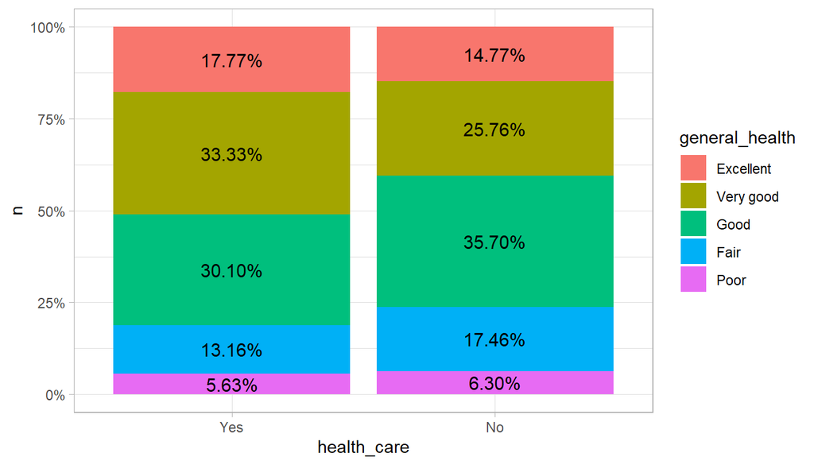

```r
group2013 %>%
  group_by(general_health, health_care) %>%
  summarise(n = n(), n_perc = prop.table(n)) %>%

  na.exclude %>%

  group_by(health_care) %>%
  mutate(n_perc = prop.table(n)) %>%
  ggplot(aes(x=health_care, y=n, label=scales::percent(n_perc), fill=general_health)) +
    geom_bar(position="fill", stat="identity") +
    geom_text(size = 4, position = position_fill(vjust = 0.5)) +
    scale_y_continuous(label = scales::percent)
```

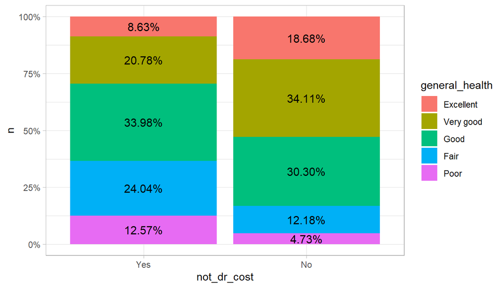

```r
group2013 %>%
  group_by(not_dr_cost, general_health) %>%
  summarise(n = n(), n_perc = prop.table(n)) %>%

  na.exclude %>%

  group_by(not_dr_cost) %>%
  mutate(n_perc = prop.table(n)) %>%
  ggplot(aes(x=not_dr_cost, y=n, label=scales::percent(n_perc), fill=general_health)) +
    geom_bar(position="fill", stat="identity") +
    geom_text(size = 4, position = position_fill(vjust = 0.5)) +
    scale_y_continuous(label = scales::percent)
```

**Evaluation** We can evaluate that the US citizens who answered ‘YES’ for Have Any Health Care Coverage have a greater representativeness in the responses of very good and excellent for general health, when compared with those who answered ‘NO’. And when we look to the question “Could Not See Dr. Because Of Cost?” we see that those who answered ‘YES’ have a greater representativeness in the responses of Poor and Fair general health.

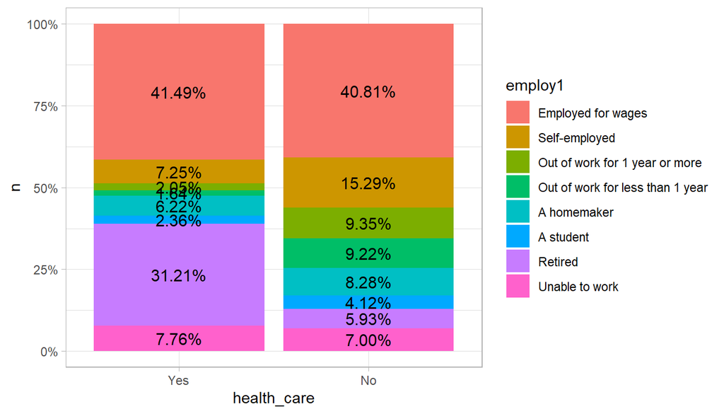

```r
group2013 %>%
  group_by(health_care, employ1) %>%
  summarise(n = n(), n_perc = prop.table(n)) %>%

  na.exclude %>%

  group_by(health_care) %>%
  mutate(n_perc = prop.table(n)) %>%
  ggplot(aes(x=health_care, y=n, label=scales::percent(n_perc), fill=employ1)) +
    geom_bar(position="fill", stat="identity") +
    geom_text(size = 4, position = position_fill(vjust = 0.5)) +
    scale_y_continuous(label = scales::percent)
```

**Evaluation** It`s curious to see that retired are more representative in citizens who respond to having health care coverage.Perhaps because they planned their future and secured this expense.

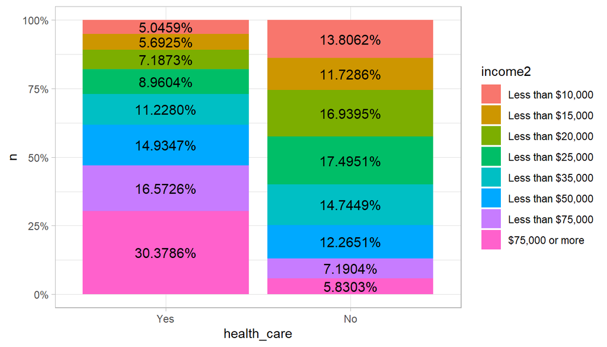

```r
group2013 %>%
  group_by(health_care, income2) %>%
  summarise(n = n(), n_perc = prop.table(n)) %>%

  na.exclude %>%

  group_by(health_care) %>%
  mutate(n_perc = prop.table(n)) %>%
  ggplot(aes(x=health_care, y=n, label=scales::percent(n_perc), fill=income2)) +
    geom_bar(position="fill", stat="identity") +
    geom_text(size = 4, position = position_fill(vjust = 0.5)) +
    scale_y_continuous(label = scales::percent)
```

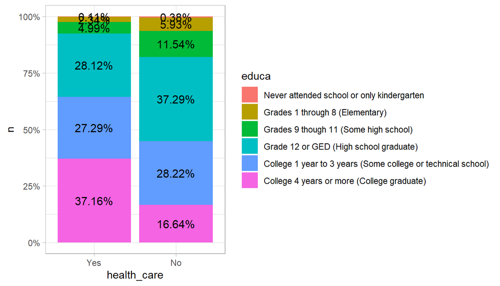

```r
group2013 %>%
  group_by(health_care, educa) %>%
  summarise(n = n(), n_perc = prop.table(n)) %>%

  na.exclude %>%

  group_by(health_care) %>%
  mutate(n_perc = prop.table(n)) %>%
  ggplot(aes(x=health_care, y=n, label=scales::percent(n_perc), fill=educa)) +
    geom_bar(position="fill", stat="identity") +
    geom_text(size = 4, position = position_fill(vjust = 0.5)) +
    scale_y_continuous(label = scales::percent)
```

**Evaluation** A large part of those with health care coverage has a college graduation and an annual household income from all sources for U$ 75,000 or more.

**Research question 3**

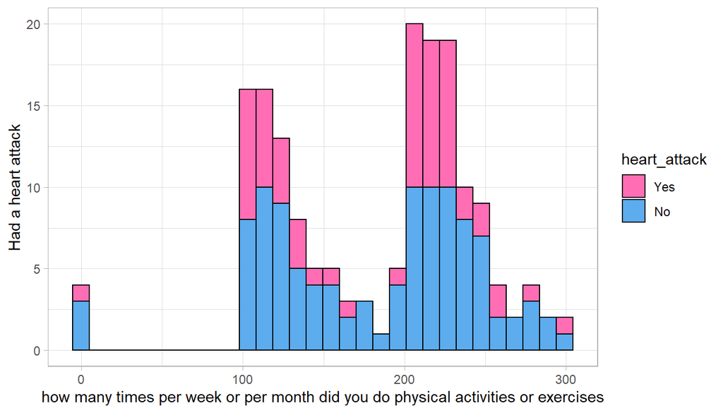

```r
group2013%>%
  group_by(heart_attack,strength) %>%
  summarise(n = n()) %>%
  na.exclude %>%
  ggplot(aes(x = strength, fill=heart_attack)) +
    geom_histogram(color="black") +
    xlab("how many times per week or per month did you do physical activities or exercises") +
    ylab("Had a heart attack") +
    scale_fill_manual(values=c("hotpink1", "steelblue2"))
```

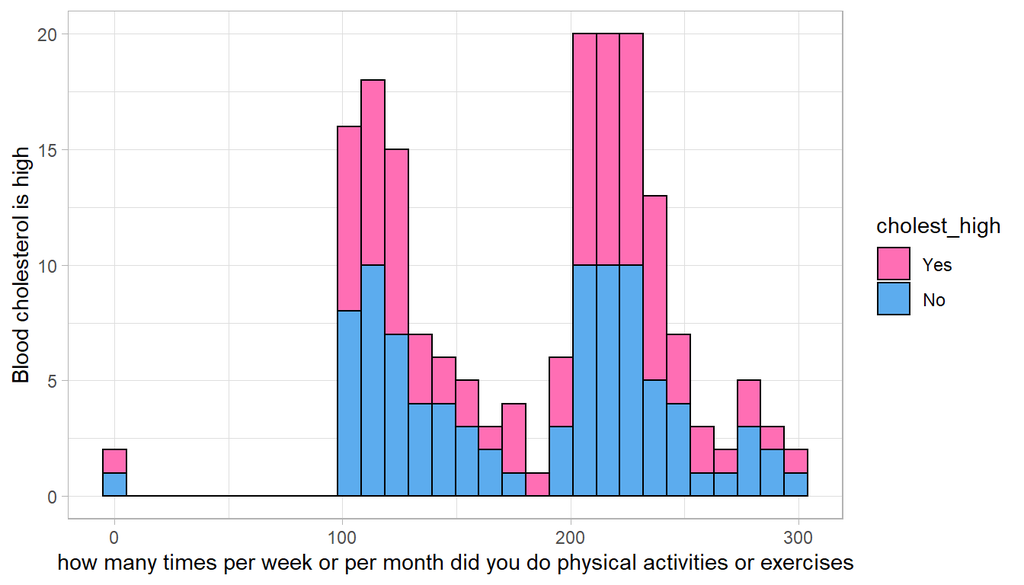

```r
group2013%>%
  group_by(cholest_high,strength) %>%
  summarise(n = n()) %>%
  na.exclude %>%
  ggplot(aes(x = strength, fill=cholest_high)) +
    geom_histogram(color="black") +
    xlab("how many times per week or per month did you do physical activities or exercises") +
    ylab("Blood cholesterol is high") +
    scale_fill_manual(values=c("hotpink1", "steelblue2"))
```

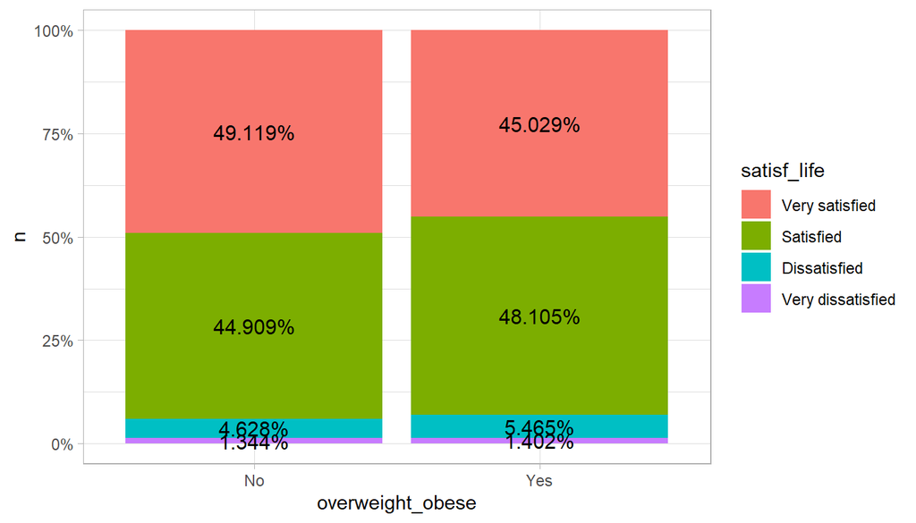

```r
  group2013 %>%
  group_by(overweight_obese, satisf_life) %>%
  summarise(n = n(), n_perc = prop.table(n)) %>%

  na.exclude %>%

  group_by(overweight_obese) %>%
  mutate(n_perc = prop.table(n)) %>%
  ggplot(aes(x=overweight_obese, y=n, label=scales::percent(n_perc), fill=satisf_life)) +
    geom_bar(position="fill", stat="identity") +
    geom_text(size = 4, position = position_fill(vjust = 0.5)) +
    scale_y_continuous(label = scales::percent)
```

In addition, in the last graph we can see that obese people or with over weight doesn’t change significant with those who aren’t, about the satisfaction with life.